# R Notebook

# t-Tests für abhängige Stichproben

## Aufgabenstellung

Eine Gruppe von 29 Teilnehmer beantworten einen ausführlichen Fragebogen zur Extraversion. Später werden die Ehepartner im Rahmen eines Fremdeinschätzungfragebogen befragt, wie extraversviert der Ehepartner ist. Es soll geprüft werden, ob die Fremd- und Selbsteinschätzung der Extraversion übereinstimmen. Bei dem Fragebogen handelt es sich um ein etablierten Extraversionsfragebogen

Der zu analysierende Datensatz enthält neben einer Probandennummer (ID) die beiden Messungen derm Extraversion(Fremdeinschätzung, Selbsteinschätzung).

## 1) Hypothese

H1: Es gibt einen Unterschied zwischen der Selbsteinschätzung und der Fremdeinschätzung durch den Ehepartner bei der Extraversion.

H0: Es gibt keinen Unterschied zwischen der Selbsteinschätzung und der Fremdeinschätzung durch den Ehepartner bei der Extraversion.

## 2) Voraussetzungen des t-Tests für abhängige Stichproben

Die abhängige Variable ist min. intervallskaliert -> Ja, Extraversion ist metrisch.

Es liegen zwei verbundene Stichproben oder Gruppen vor, aber die verschiedenen Messwertpaare sind voneinander unabhängig. 1) Sie sind verbundenen durch die Ehe, 2) aber unabhängige, weil es zwei verschiedene Messpaare (A und B) sind.

Die Unterschiede zwischen den verbundenen Testwerten sind in der Grundgesamtheit normalverteilt (bei Stichproben > 30 sind Verletzungen unproblematisch)

### Erzeuge neue Variable:

```r
# Differenz erstellen
zwischen <- ttestVER$Fremdeinschaetzung - ttestVER$Selbsteinschaetzung
zwischen
```

```
 [1]  -5  -6  -3  -6   0   3  -8  -3  -3  -3  -7   0  -5  -9  -3  -3  -8  -6  -5  -8 -11  -4 -10  -2  -1  -1 -12
[28]  -6  -2
```

```r
# Die Spalte "Differenz" wird zum Datensatz hinzugefügt
ttestVER <- cbind(ttestVER, "Differenz" = zwischen)
View(ttestVER)
```

```r
# Eine Spalte löschen

ttestVER$Differenz <- NULL
#View(ttestVER)
```

```r
# Falls es Probleme gibt
# ttestVER$Differenz <- as.numeric(ttestVER$Differenz)
```

### Pruefung der Verteilung:

#### Histogramm zur Prüfung des Normalverteilung

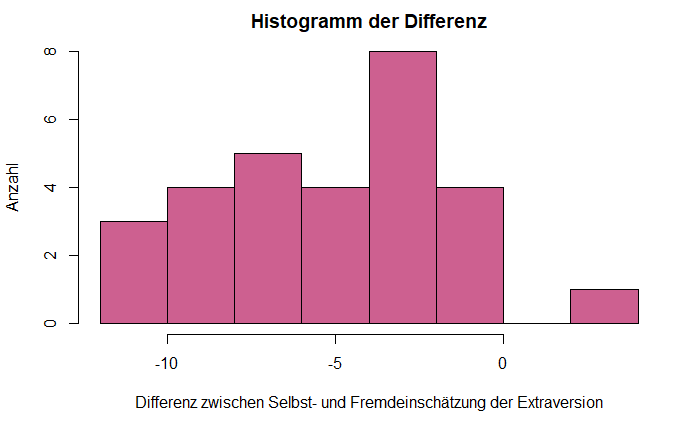

```r
hist(ttestVER$Differenz, xlab = "Differenz zwischen Selbst- und Fremdeinschätzung der Extraversion", ylab= "Anzahl", main ="Histogramm der Differenz", breaks =6,  col = "hotpink3")
```

#### ALTERNATIVE: QQ-Diagramm zur Prüfung des Normalverteilung:

Deine Werte müssen entlang einer aufsteigenden Gerade liegen, so dass Du eine ähnliche Verteilung vermuten kannst.

```
[1]  6 27
```

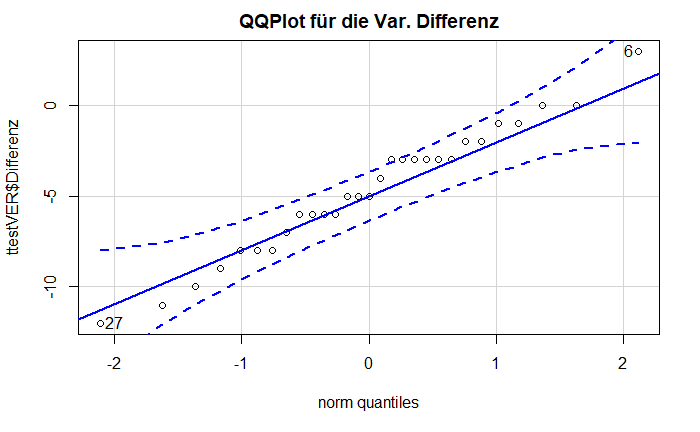

```r
library(car)
qqPlot(ttestVER$Differenz, main = "QQPlot für die Var. Differenz")
```

Es gibt eine Normalverteilung.

## 3) Grundlegende Konzepte: Was ist t-Test für abhängige Stichproben?

Der t-Test für abhängige Stichproben überprüft, ob die Mittelwerte zweier abhängiger/gepaarter Stichproben verschieden sind.

## 4) Deskriptive Statistiken und Korrelation

### Korrelation:

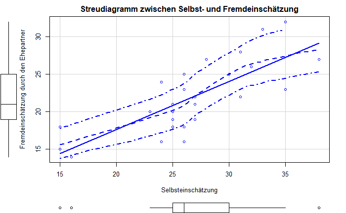

```r
#library(car)
scatterplot(ttestVER$Fremdeinschaetzung ~ ttestVER$Selbsteinschaetzung , main = "Streudiagramm zwischen Selbst- und Fremdeinschätzung", xlab = "Selbsteinschätzung", ylab= "Fremdeinschätzung durch den Ehepartner")
```

```r
test <- cor.test(ttestVER$Selbsteinschaetzung, ttestVER$Fremdeinschaetzung)
test
```

```
    Pearson's product-moment correlation

data:  ttestVER$Selbsteinschaetzung and ttestVER$Fremdeinschaetzung
t = 6.1783, df = 27, p-value = 1.324e-06
alternative hypothesis: true correlation is not equal to 0
95 percent confidence interval:
 0.5542825 0.8838955
sample estimates:
     cor
0.765316
```

Die Fremdeinschätzung durch den Ehepartner und die Selbsteinschätzung korrelieren positiv-linear signifikant (r = .77, p = .000, n = 29).

Bei Messwiederholungen ist es möglich, dass die Daten der ersten und zweiten Erhebung (respektive eines Messwertpaars) miteinander korrelieren. Es ist plausibel, dass zwei verbundene Messungen sich ähnlich sind und dass innerhalb eines Messwertpaares eher geringere Unterschiede auftreten als zwischen den Paaren.

Im R-Output wird daher eine Pearson Korrelation der beiden Messzeitpunkte ausgegeben. Für das Beispiel ergibt sich eine sehr hohe Korrelation von r = .77 (p = .000, n = 29).

### Deskriptive Statistiken:

```r
library(psych)
g <- describe(ttestVER)
g
```

|  | vars | n | mean | sd | median | trimmed | mad | min | max | range | skew | kurtosis | se |
| --- | --- | --- | --- | --- | --- | --- | --- | --- | --- | --- | --- | --- | --- |
| Fremdeinschaetzung | 1 | 29 | 21.79 | 4.55 | 21 | 21.60 | 4.45 | 14 | 32 | 18 | 0.40 | -0.56 | 0.85 |
| Selbsteinschaetzung | 2 | 29 | 26.52 | 5.44 | 26 | 26.64 | 2.97 | 15 | 38 | 23 | -0.20 | 0.11 | 1.01 |
| Differenz | 3 | 29 | -4.72 | 3.52 | -5 | -4.68 | 2.97 | -12 | 3 | 15 | -0.11 | -0.55 | 0.65 |

Es zeigt sich, dass es einen Mittelwertsunterschied zwischen Fremdeinschätzung durch den Ehepartner und der Selbsteinschätzung in Punkto Extraversion gibt. Die Mittelwerte unterscheiden sich dahingehend, das die Fremdeinschätzung bei 21.79 (SD = 4.55, n= 29), wohingegen die Selbsteinschätzung bei 26.51 (SD = 5.44 ,n=29) liegt.

## 5) Ergebnisse des t-Tests für abhängige Stichproben

```r
testVER<- t.test(ttestVER$Selbsteinschaetzung, ttestVER$Fremdeinschaetzung, alternative = "two.sided", paired = TRUE, conf.level = .95)

testVER
```

```
    Paired t-test

data:  ttestVER$Selbsteinschaetzung and ttestVER$Fremdeinschaetzung
t = 7.2184, df = 28, p-value = 7.402e-08
alternative hypothesis: true difference in means is not equal to 0
95 percent confidence interval:
 3.383539 6.064736
sample estimates:
mean of the differences
               4.724138
```

Die Teststatistik beträgt t = 7.218 und der zugehörige Signifikanzwert p = 7.402e-08. Damit ist der Unterschied signifikant: Die Mittelwerte der beiden Messzeitpunkte (Fremdeinschätzung und Selbsteinschätzung) unterscheiden sich (t(28) = 7.218, p = 7.402e-08, n= 29).

## 6) Berechnung der Effektstärke

### Cohen und Pearson:

```r
eff1 <- abs(sqrt(testVER$statistic^2 / (testVER$statistic^2 + testVER$parameter)))

sprintf("Effektstärke: %.4f",eff1)
```

```
[1] "Effektstärke: 0.8065"
```

Damit entspricht eine Effektstärke von 0.8 einem starken Effekt

### ALTERNATIV: Hedges g

```r
diff <- testVER$estimate

sed <- sd(ttestVER$Fremdeinschaetzung - ttestVER$Selbsteinschaetzung)

g <- diff/sed

sprintf("Effektstärke: %.4f",g)
```

```
[1] "Effektstärke: 1.3404"
```

Zur Beurteilung der Größe des Effektes: Damit entspricht eine Effektstärke von 1.3 einem starken Effekt.

## 7) Eine Aussage:

Es zeigt sich, dass die Extraversionswerte sowohl von der Fremdeinschätzung als auch der Selbsteinschätzung statistisch signifikant sich unterscheiden (t(28) = 7.21, p = .000, n = 29). Die Selbsteinschätzung der Extraversion fällt höher aus (M = 26.51, SD = 5.44) als die Fremdeinschätzung durch den Ehepartner (M = 21.79, SD = 4.55). Die Effektstärke nach Cohen (1992) liegt bei r = 0.8 und entspricht damit einem starken Effekt. H0 kann verworfen werden.